# Homework 4

*Enter your name and EID here*

**This homework is due on Feb. 15, 2021 at 11:00pm. Please submit as a pdf file on Canvas.**

**Problem 1: (5 pts)** We will work with the `midwest` dataset provided by **ggplot2**. See here for details: https://ggplot2.tidyverse.org/reference/midwest.html

For the following plot, add an appropriate color scale from the **colorspace** package and explicitly set the palette you want to use. Also add an appropriate theme that works well with the color scale you have chosen. Explain in 2-3 sentences your choice of color scale and theme.

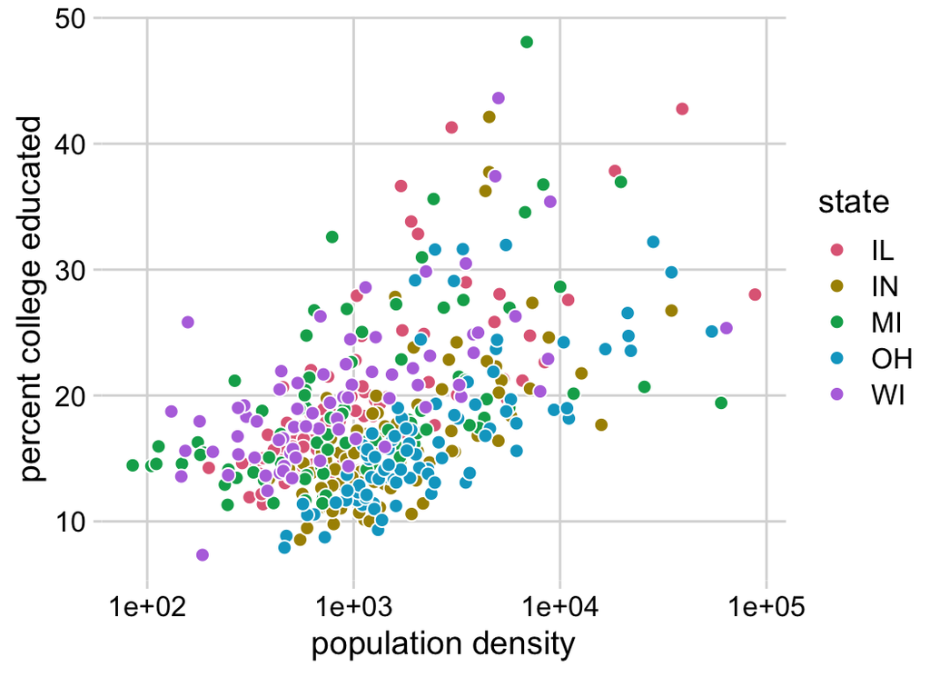

```r
ggplot(midwest, aes(popdensity, percollege, fill = state)) +
  geom_point(shape = 21, size = 2.5, color = "white", stroke = 0.5) +
  scale_x_log10(name = "population density") +
  scale_y_continuous(name = "percent college educated") +
  scale_fill_discrete_qualitative(palette = "Dark3") +
  theme_minimal_grid()
```

We need a scale for the `fill` aesthetic, and the `state` variable is discrete and unordered. Therefore, we need a discrete, qualitative color scale, i.e., `scale_fill_discrete_qualitative()`. I picked palette “Dark3” because it is overall the darkest palette available, and it makes the points stand out from the background. I chose `theme_minimal_grid()` because it is very minimal and helps the data points stand out.

**Problem 2: (2 pts)** The following is a plot of the `diamonds` dataset provided by **ggplot2**. See here for details: https://ggplot2.tidyverse.org/reference/diamonds.html

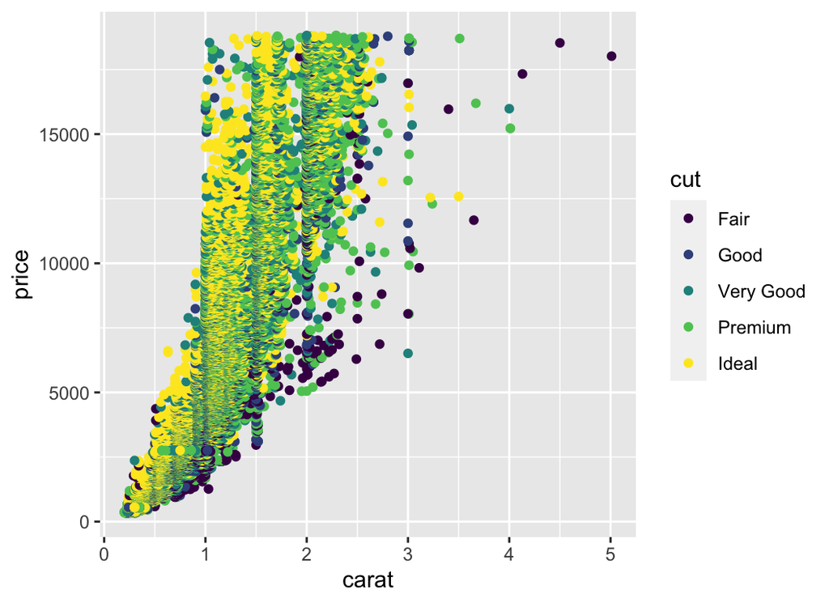

```r
ggplot(diamonds, aes(carat, price, color = cut)) +
  geom_point()
```

As you can see, if we don’t specify a color scale ggplot chooses the viridis scale by default. Explain in 2-3 sentences why the viridis scale is an appropriate choice here.

The viridis scale is appropriate because it is a sequential scale, and it is used here to represent categorical ordered data. The values for `cut` (Ideal, Premium, Very Good, etc.) are not numeric but they have a clear ordering, and the sequential nature of the viridis scale shows this ordering.

**Problem 3: (3 pts)** For this problem, we will go back to the `midwest` dataset. In the following plot, you may notice that the axis tick labels are smaller than the axis titles, and also in a different color (gray instead of black). Make the axis tick labels the same size (`size = 12`) and give them the color black (`color = "black"`). Then, set the entire plot background to the color `"#F3F8FF"`. Make sure there are no white areas remaining, such as behind the plot panel or under the legend.

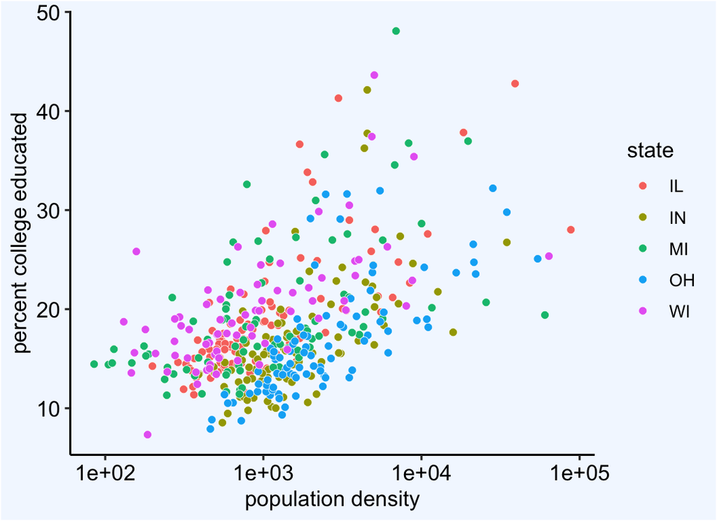

```r
ggplot(midwest, aes(popdensity, percollege, fill = state)) +
  geom_point(shape = 21, size = 2, color = "white", stroke = 0.2) +
  scale_x_log10(name = "population density") +
  scale_y_continuous(name = "percent college educated") +
  theme_classic(12) +
  theme(
    axis.text = element_text(color = "black", size = 12),
    plot.background = element_rect(fill = "#F3F8FF"),
    panel.background = element_blank(),
    legend.background = element_blank()
  )
```